# Exploring the Effects of Student Alcohol Consumption

Connor Toliver and Haley Humphries; GitHub: @connortoliver and @haley22

5/4/2020

## Student Alcohol Consumption

Alcohol is a one of the most used drugs in the world by people, and college students are no excception. Many people have grown up around it their entire lives and seen the effects first-hand, while others have heard anecdotes about it. Using the Student Alcohol Consumption data set from University of California-Irvine Machine Learning on Kaggle, we can analyze several attributes of people’s lives in relation to their alcohol consumption to see the effects it has on students.

## Loading and Prepping the Data

Before we begin, let’s first quickly load in the data and prep it. This means joining our tables, selecting the variables we’ll use, and factoring some of the variables.

```r
library(tidyverse)
datMat <- read.table("student-mat.csv",sep=",",header=TRUE)
datPor <- read.table("student-por.csv",sep=",",header=TRUE)

dat <- datMat %>%  inner_join(datPor, by=c("school", "sex", "age", "address", "famsize","Pstatus", "Medu", "Fedu", "Mjob", "Fjob", "reason", "nursery", "internet"), suffix=c(".Mat", ".Por"))

dat <- dat %>%
  select('school', 'sex', 'age', 'address', 'famsize', 'Pstatus', 'Medu', 'Fedu', 'Mjob', 'Fjob', 'reason', guardian = 'guardian.Mat', traveltime = 'traveltime.Mat', studytime = 'studytime.Mat', failures = 'failures.Mat', schoolsup = 'schoolsup.Mat', famsup = 'famsup.Mat', paid = 'paid.Mat', activities = 'activities.Mat', 'nursery', higher = 'higher.Mat', 'internet', romantic = 'romantic.Mat', famrel = 'famrel.Mat', freetime = 'freetime.Mat', goout = 'goout.Mat', Dalc = 'Dalc.Mat', Walc = 'Walc.Mat', health = 'health.Mat', absences = 'absences.Mat', 'G1.Mat', 'G2.Mat', 'G3.Mat', 'G1.Por', 'G2.Por', 'G3.Por')


dat$Dalc <- factor(dat$Dalc, levels=c(5, 4, 3, 2, 1))
dat$Walc <- factor(dat$Walc, levels=c(5, 4, 3, 2, 1))
dat$famrel <- factor(dat$famrel, levels=c(1, 2, 3, 4, 5))
```

## Exploring the Data

Now that we have the data loaded and ready to go, let’s look at what the data tells us. Initially, we had a few questions we tried to answer:

- Does whether a student has any educational support have an effect on their alcohol consumption?
- What is the quality of family relationships as it relates to alcohol consumption?
- Do students who spend more of their free time drinking have an effect on their final grades?
- Does weekly alcohol consumption have an effect on health status, number of absences, or grades?
  - What about weekend alcohol consumption?
  - Does age or gender have any effect on this as well?

### Alcohol consumption & educational support

Much of the data set has variables based on a 1-5 scale. For example, weekday and weekend alcohol consumption are rated on a 1-5 scale; 1 meaning little to no alcohol, and 5 meaning a very high intake of alcohol.

We thought it would be interesing to look at the relationship between alcohol consumption and educational support. Our hypothesis was that students with more educational support would have higher amounts of of alcohol consumption than those who don’t, because students who receive more educational support have more time and ability to drink more. While weekday drinking was slightly higher for students with educational support, weekend drinking was a surprise.

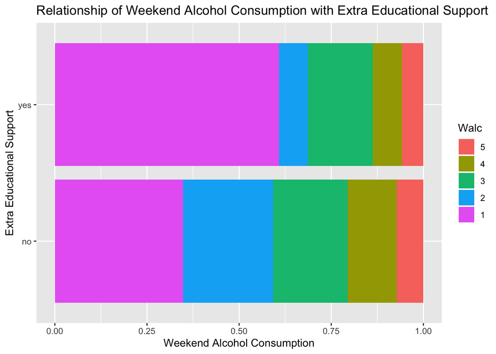

```r
dat %>%
  ggplot(aes(x=schoolsup, fill=Walc)) +
  geom_bar(position='fill') +
  coord_flip() +
  xlab('Extra Educational Support') +
  ylab('Weekend Alcohol Consumption') +
  ggtitle('Relationship of Weekend Alcohol Consumption with Extra Educational Support')
```

Students who received educational support actually had a higher percentage of students who drank little to no alcohol than students who received no educational support. In fact, the percentage of students who ranked their alcohol consumption as “5” was lower compared to students who received no educational support. Perhaps certain educational support such as weekend tutoring is the cause of this, since students are more focused on their education on the weekends than those who do not receive support.

### Alcohol consumption & family relationships

Next, we wanted to look at alcohol consumption and how they relate to family relationships. We hypothesized that the higher the alcohol consumption, the higher the percentage of people who had lower quality familiy relationships. The results are clear and come as no surprise:

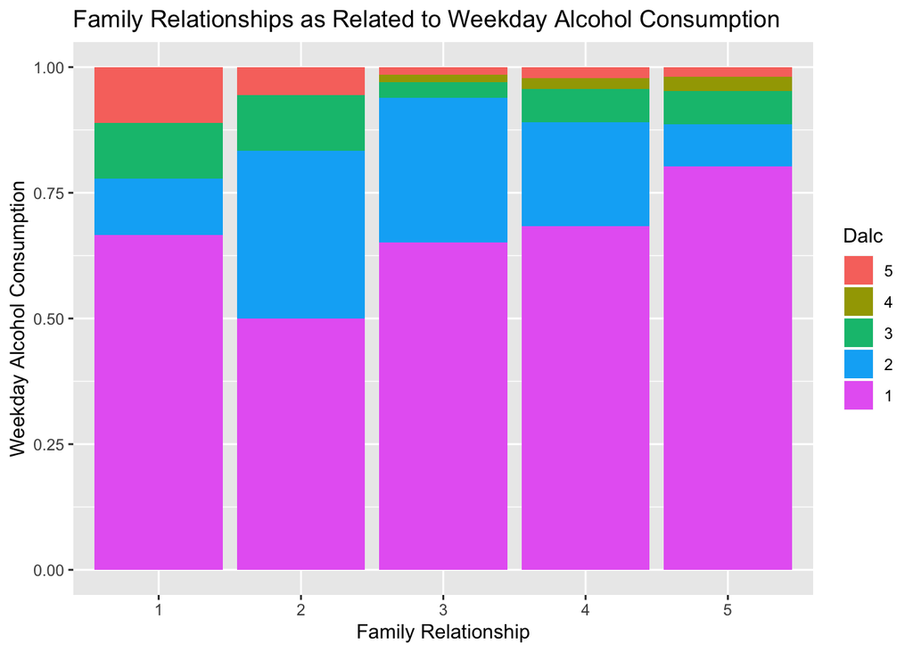

```r
dat %>%
  ggplot(aes(famrel, fill=Dalc)) +
  geom_bar(position='fill') +
  xlab('Family Relationship') +
  ylab('Weekday Alcohol Consumption') +
  ggtitle('Family Relationships as Related to Weekday Alcohol Consumption')
```

As you can see, students who rated their family relationships as lower quality saw a larger percentage of weekday high alcohol consumption. However, when compared to weekend alcohol consumption, the results are even more clear:

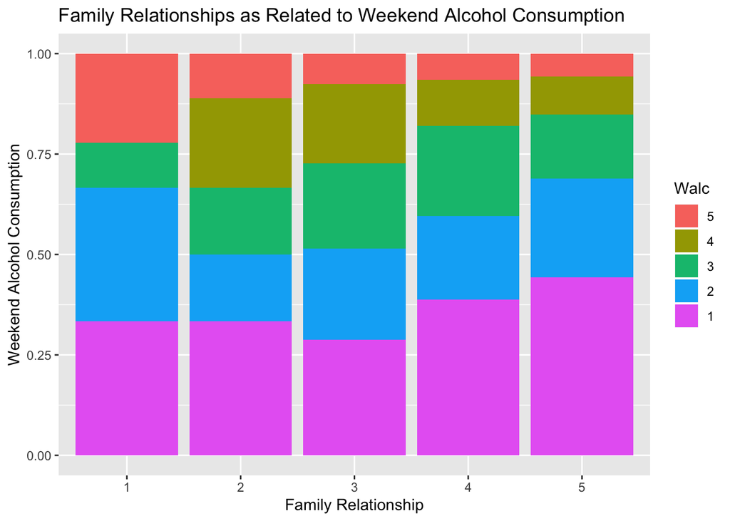

```r
dat %>%
  ggplot(aes(famrel, fill=Walc)) +
  geom_bar(position='fill') +
  xlab('Family Relationship') +
  ylab('Weekend Alcohol Consumption') +
  ggtitle('Family Relationships as Related to Weekend Alcohol Consumption')
```

Nearly 25% of respondents with a family relationship of 1 had a very high weekend alcohol consumption of 5. As the relationship gets better, the percentage of high amounts of alcohol consumption clearly decreases. This tells us that students who drink more have worse family relationships, which fits with our initial hypothesis.

### Alcohol consumption, freetime, & finals

Final grades are an often dreaded part of any semester, but what effect does it have on grades? And does freetime have any effect either? We hypothesized that students who drink more – especially those who rate their alcohol consumption at a 4 or 5 – will have worse final grades, and that students with more free time will have higher grades.

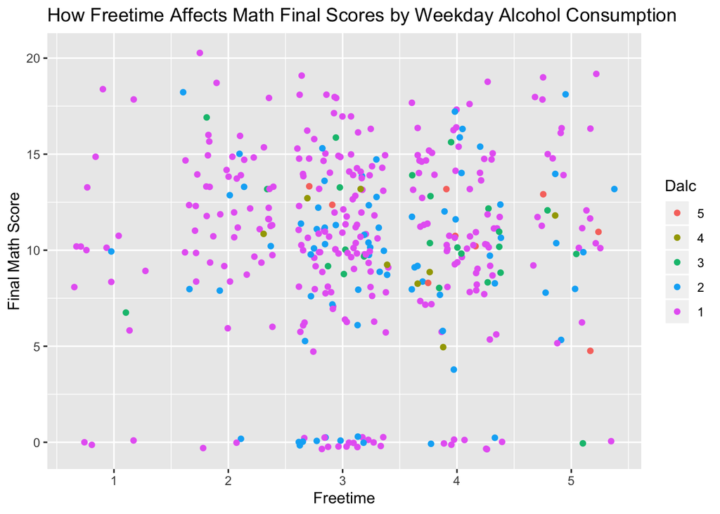

```r
dat %>%
  ggplot(aes(freetime, G3.Mat, color=Dalc)) +
  geom_jitter() +
  xlab('Freetime') +
  ylab('Final Math Score') +
  ggtitle('How Freetime Affects Math Final Scores by Weekday Alcohol Consumption')
```

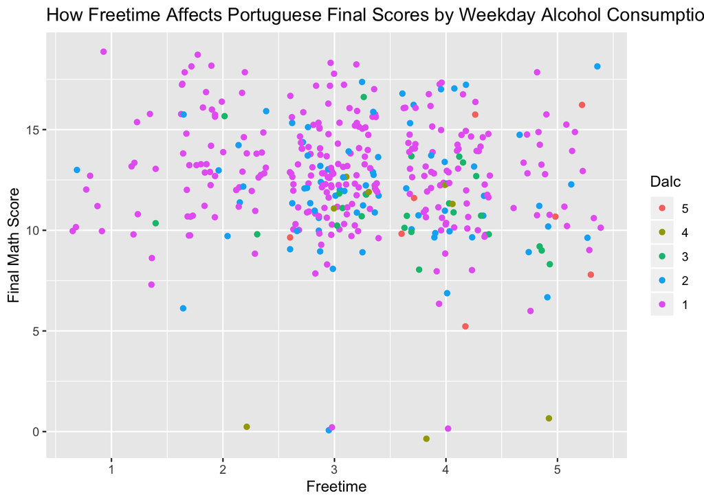

```r
dat %>%
  ggplot(aes(freetime, G3.Por, color=Dalc)) +
  geom_jitter() +
  xlab('Freetime') +
  ylab('Final Math Score') +
  ggtitle('How Freetime Affects Portuguese Final Scores by Weekday Alcohol Consumption')
```

Surprisingly, neither alcohol consumption nor freetime had much of an effect at all. Students with high alcohol consumptions didn’t stray far from the middle range of grades around 7.5 to 12.5, but there are no real discernible correlations, and the same goes for freetime.

Both of these are especially interesting. Growing up, you often hear how bad the effects of alcohol are on grades and schoolwork, but this doesn’t point to that at all. That’s not to advocate for using/abusing alcohol at all; rather, it’s interesting to see how this data doesn’t point to those effects.

### Alcohol Consumption, Health, Grades, and Absences

Another question we looked at was what kind of affect, if any at all, weekday alcohol consumption has on health, number of absences, and grades. This displays all levels of health at both ends of the alcohol consumption spectrum (5 being a lot of alcohol consumed and 1 being little or no alcohol consumed, health being really good at 1, and really poor at 5). We are shown that those with very good health tend to drink less than others. There are a few instances of people who drink fairly often still being in good health but we have to take into account that our data set includes 15-22 year olds, a group of people that is generally pretty healthy. There are also a few cases of people who do not consume much, if any, alcohol having bad health but we also must take into account that some people have pre-existing health conditions and the likelyhood of people having alcohol related health issues at this age is very uncommon. Also included in the analysis is if weekend alcohol consumption has an effect on health, number of absences, and grades. It provided pretty similar findings as before. It is also somewhat difficult to work with health when there is not much context. For example, what makes someone a 5? What makes them a 1? Also included are the average grades for both ends of the spectrum for weekly alcohol consumption to give us an idea on how well that student does in school based on if they consume much alcohol and I wanted to take account of the average grade for each level of health. So in the first table we have those who consumed the most alcoholand the second is those who consume little or no alcohol.

```r
dat %>%
  group_by(Walc, health) %>%
  filter(Walc == '5') %>%
  summarise(`Average grade` = mean(G1.Mat)+mean(G2.Mat)+mean(G3.Mat)) %>%
  arrange(desc(`Average grade`)) %>%
  arrange(desc(Walc))
```

```
## # A tibble: 5 x 3
## # Groups:   Walc [1]
##   Walc  health `Average grade`
##   <fct>  <int>           <dbl>
## 1 5          4            31.4
## 2 5          3            31.4
## 3 5          2            31
## 4 5          5            29.9
## 5 5          1            29
```

```r
dat %>%
  group_by(Walc, health) %>%
  filter(Walc == '1') %>%
  summarise(`Average grade` = mean(G1.Mat)+mean(G2.Mat)+mean(G3.Mat)) %>%
  arrange(desc(`Average grade`)) %>%
  arrange(desc(Walc))
```

```
## # A tibble: 5 x 3
## # Groups:   Walc [1]
##   Walc  health `Average grade`
##   <fct>  <int>           <dbl>
## 1 1          1            35.7
## 2 1          4            32.8
## 3 1          5            32.4
## 4 1          2            32.4
## 5 1          3            30.8
```

There is definitely a difference between average grades of those who drink and those who don’t. However it is not as much of a difference as some might expect, including myself. This could be because those who are consuming a good amount of alcohol can still be responsible for their school work and prioritize. Alcohol consumption also has a bigger effect on health as you get older, not when you are practically in your prime.

Next, I went on to look at average absences at each level of weekday alcohol consumption. It shows pretty much what you would expect. If you are drinking a lot on weekdays, you are probably going to be showing up to fewer classes.

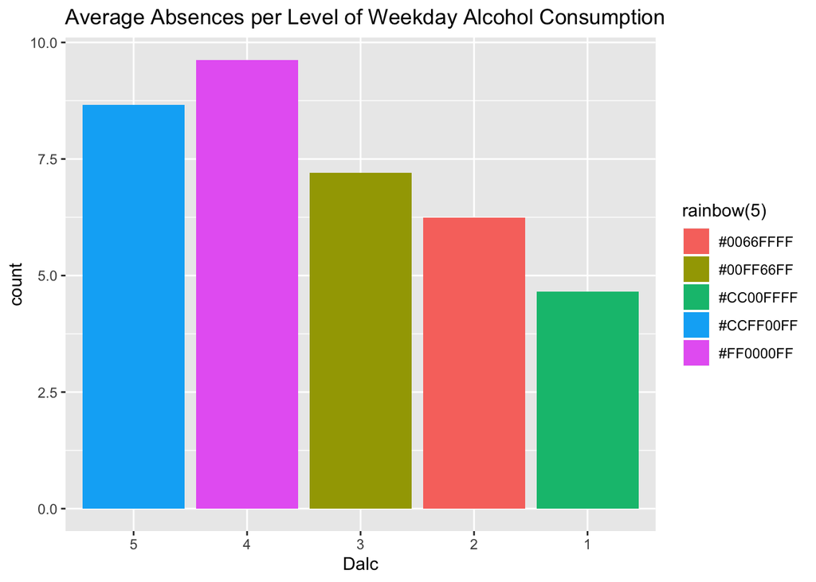

```r
dat %>%
  group_by(Dalc) %>%
  summarise(`Average absences` = mean(absences)) %>%
  arrange(desc(`Average absences`)) %>%
  ggplot(aes(x= Dalc, weight = `Average absences`, fill = rainbow(5))) + ggtitle('Average Absences per Level of Weekday Alcohol Consumption') + geom_bar()
```

### Grades by Age and Alcohol Consumption

Finally, I wanted to look at these same variables while also taking into account age and gender. Since the age range in our data set goes from 15-22, I decided the best way to split it up was to look at high schoolers, versus college students. I included ages 15-18 for high school and ages 19-22 for college students. High school students have higher average grades than college students at all levels of alcohol consumption, which is what you might expect since high school is generally much easier than college and there is probably less drinking involved in high school too.

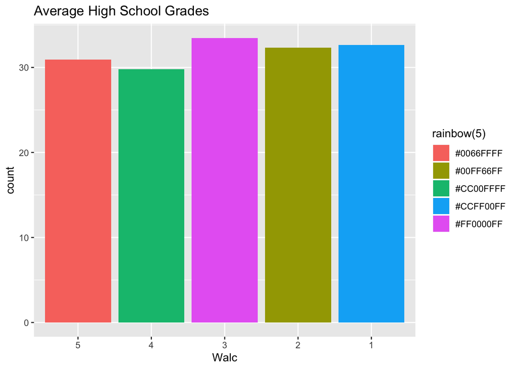

```r
dat %>%
  group_by(Walc) %>%
   filter(age <= '18') %>%
  summarise(`Average grade` = mean(G1.Mat)+mean(G2.Mat)+mean(G3.Mat)) %>%
  arrange(desc(`Average grade`)) %>%
  ggplot(aes(x= Walc, weight = `Average grade`, fill = rainbow(5))) + ggtitle('Average High School Grades') + geom_bar()
```

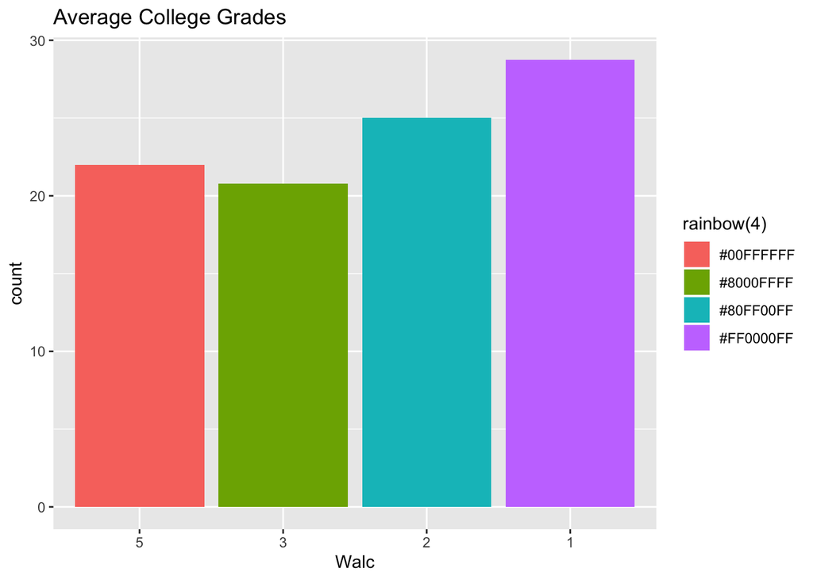

```r
dat %>%
  group_by(Walc) %>%
   filter(age >= '19') %>%
  summarise(`Average grade` = mean(G1.Mat)+mean(G2.Mat)+mean(G3.Mat)) %>%
  arrange(desc(`Average grade`)) %>%
  ggplot(aes(x= Walc, weight = `Average grade`, fill = rainbow(4))) + ggtitle('Average College Grades') + geom_bar()
```

## Contributions

### Connor Toliver

For this project, I handled the analysis for the first three questions raised in the report and presentation. I was also the project coordinator and handled recording and uploading the presentation, the GitHub repository, and communications with the instructor and TA.

### Haley Humphries

For this project I, Haley Humphries, did the analysis for the last three questions seen in our presentation, created those slides, and wrote the second half of this report about some of my findings in my analysis.

## Conclusions

We reached a few interesting conclusions during this exploratory analysis of student alcohol consumption.

## Sources

[The Student Alcohol Consumption data set from University of California-Irvine Machine Learning on Kaggle](https://www.kaggle.com/uciml/student-alcohol-consumption)